# Unemployment in Spain

Pablo Ugarte

2017-09-15

# Intro

> In this post, we scrape data and data wrangle to get an overall picute of the job market.

The data comes from the Instituto Nacional de Estadistica (INE) website [^1].

# Libraries

Overall, we are going to use the following R packages:

```r
library(XML) # For web scraping
library(rvest) # For web scraping
library(dplyr) # For dataset manipulation
library(hrbrthemes) # Aesthetic defaults for ggplot2 charts
library(ggthemes) # Themes ggplot2
library(ggplot2) # Charts
library(stringr) # Manipulating strings
library(tidyverse) # Data wrangling packages gather, spread...
library(lubridate) # To work with dates
library(ggthemes) # Themes ggplot
```

# Scraping

With the rvest package we can scrape the content of the table.

- We first use the html_nodes() function to select the

  nodes

  To parse the HTML table data we use html_table(), which would create a list

  We coerce the list to dataframe to be able to work with the data manipulaton

  ```r
  webpage <- read_html("http://www.ine.es/prensa/epa_tabla.htm")

  # Only parse the table interested
  tbl_ine <- webpage %>%
          html_nodes("table") %>%
          .[2] %>%
          html_table(fill = TRUE)

  # Coerce list to dataframe
  tbl_ine <- as.data.frame(tbl_ine)
  ```

# Cleansing

  For instance, if you look at tbl_ine, readHTMLTable has stripped and replaced the headings with generic names because R does not know which variable names should align with each column. We can correct for this with the following:
  - Rename column names
  - Replace the “,” with “.”
  - Select Labor Participation Rate and Unemployment Rate
  - Remove first rows with no meaningfull data
  - Convert character to numeric
  - Add column “Non-participation Rate”
  - Gather each metric variable (“Labor Participation Rate”, “Unemployment Rate”) within one column variable and also gather the values associated with each metal in a second column variable
  - Divide by 100 for % in plot y axis
  - Convert to date

  ```r
  colnames(tbl_ine) <- c("date", "activos", "ocupados",
                              "parados", "Labor Participation Rate", "Unemployment Rate")

  tbl_ine <- tbl_ine %>%
      mutate(`Labor Participation Rate` = str_replace(`Labor Participation Rate`, ",", ".")) %>%
      mutate(`Unemployment Rate` = str_replace(`Unemployment Rate`, ",", "."))

  tbl_ine <- tbl_ine %>%
             select(1,5,6) %>%
             slice(3:n())

  tbl_ine$`Labor Participation Rate` <- as.numeric(tbl_ine$`Labor Participation Rate`)
  tbl_ine$`Unemployment Rate` <- as.numeric(tbl_ine$`Unemployment Rate`)

  tbl_ine <- tbl_ine %>%
      mutate(`Non-participation Rate` = 100 - `Labor Participation Rate`) %>%
      gather(metric, ratio, 2:4)

  tbl_ine <- tbl_ine %>% mutate(ratio = ratio/100)

  tbl_ine <- tbl_ine %>%
      mutate(date = str_replace(date, "1T ", "01-03-"),
      date = str_replace(date, "2T ", "01-06-"),
      date = str_replace(date, "3T ", "01-09-"),
      date = str_replace(date, "4T ", "01-12-"))

  tbl_ine$date <- dmy(tbl_ine$date)
  ```

# Plot

  About 41% of the population is not actively engaged in the labor force, taking us back to 2007 levels.

  It’s important to keep in mind that individuals in this category include for example retired, full-time students or stay at home mom’s/dad’s.

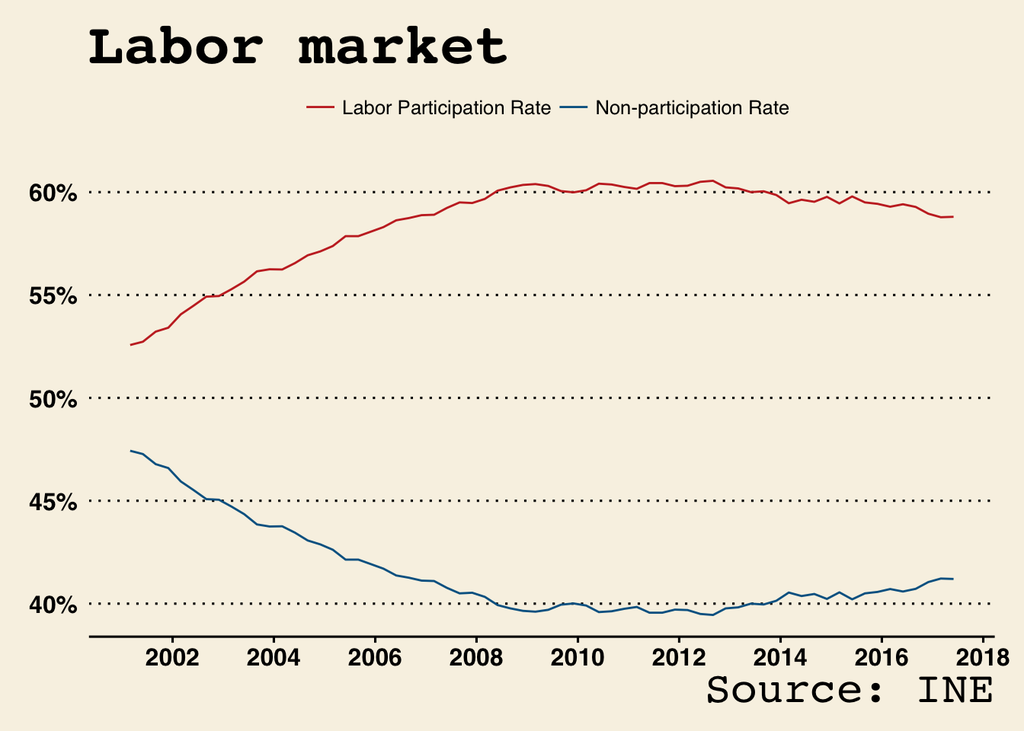

  ```r
  particpation <- tbl_ine %>% filter(metric != "Unemployment Rate")
  ggplot(particpation,aes(x=date,y=ratio,color=metric)) +
  geom_line(alpha=1) +
  theme_ipsum(grid_col = "white") +
  labs(
      title='Labor market',
      caption='Source: INE') +
  scale_y_continuous(labels=scales::percent) +
  scale_x_date(date_labels = "%Y", date_breaks = "2 years")  +
  theme_wsj() +
  scale_colour_wsj("colors6", "") +
  theme(legend.title=element_blank())
  ```

  Unemployment rate in Spain is going down but remains alarmingly high - of the highest unemployment rate in Europe and youth particularly (unfortunately I am today one of them - should have stayed in London? :).

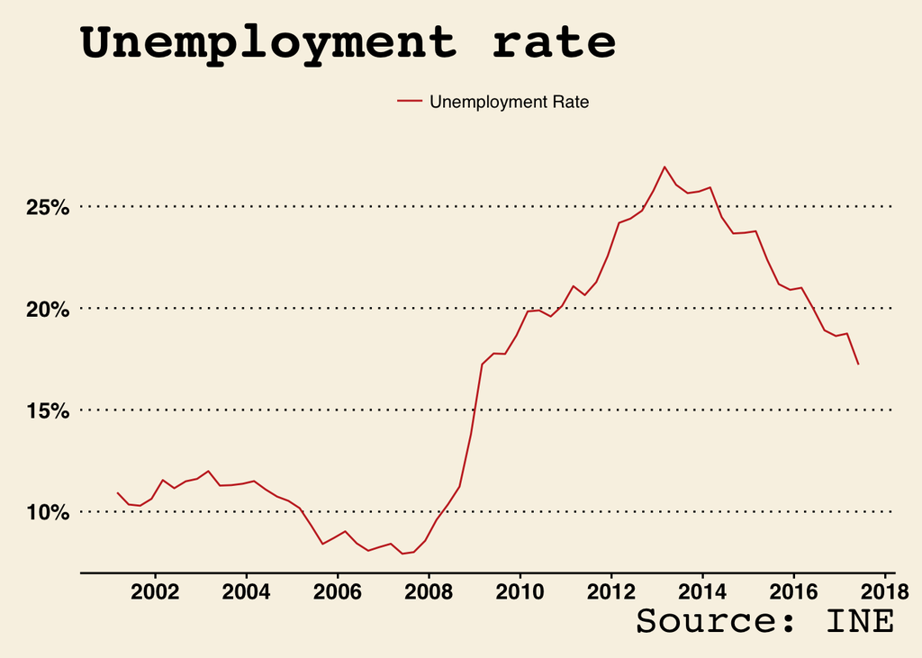

  ```r
  particpation <- tbl_ine %>% filter(metric == "Unemployment Rate")
  ggplot(particpation,aes(x=date,y=ratio,color=metric)) +
  geom_line(alpha=1) +
  theme_ipsum(grid_col = "white") +
  labs(
      title='Unemployment rate',
      caption='Source: INE') +
  scale_y_continuous(labels=scales::percent) +
  theme_wsj() +
  scale_colour_wsj("colors6", "") +
  scale_x_date(date_labels = "%Y", date_breaks = "2 years")  +
  theme(legend.title=element_blank())
  ```

  That’s it - a simple post showing the labor market in Spain!
  [^1]: INE (http://www.ine.es/prensa/epa_tabla.htm)